# Project : Movies Data Analysis

## Data Analysis & Data Presentation

### (Movies Dataset)

#### Done on May 2020

## Step 1 : Data Preprocessing and Linear Analysis

```python
import pandas as pd
import matplotlib.pyplot as plt
import numpy as np
pd.options.display.max_columns = 25
pd.options.display.float_format = '{:.2f}'.format
```

```python
## Read the csv file; change date col as release_date
df = pd.read_csv("movies_complete.csv", parse_dates= ["release_date"])
```

```python
## Observe the columns of database
df.info()
```

```
<class 'pandas.core.frame.DataFrame'>
RangeIndex: 44691 entries, 0 to 44690
Data columns (total 22 columns):
 #   Column                 Non-Null Count  Dtype
---  ------                 --------------  -----
 0   id                     44691 non-null  int64
 1   title                  44691 non-null  object
 2   tagline                20284 non-null  object
 3   release_date           44657 non-null  datetime64[ns]
 4   genres                 42586 non-null  object
 5   belongs_to_collection  4463 non-null   object
 6   original_language      44681 non-null  object
 7   budget_musd            8854 non-null   float64
 8   revenue_musd           7385 non-null   float64
 9   production_companies   33356 non-null  object
 10  production_countries   38835 non-null  object
 11  vote_count             44691 non-null  float64
 12  vote_average           42077 non-null  float64
 13  popularity             44691 non-null  float64
 14  runtime                43179 non-null  float64
 15  overview               43740 non-null  object
 16  spoken_languages       41094 non-null  object
 17  poster_path            44467 non-null  object
 18  cast                   42502 non-null  object
 19  cast_size              44691 non-null  int64
 20  crew_size              44691 non-null  int64
 21  director               43960 non-null  object
dtypes: datetime64[ns](1), float64(6), int64(3), object(12)
memory usage: 7.5+ MB
```

```python
df.head(5)
```

|  | id | title | tagline | release_date | genres | belongs_to_collection | original_language | budget_musd | revenue_musd | production_companies | production_countries | vote_count | vote_average | popularity | runtime | overview | spoken_languages | poster_path | cast | cast_size | crew_size | director |
| --- | --- | --- | --- | --- | --- | --- | --- | --- | --- | --- | --- | --- | --- | --- | --- | --- | --- | --- | --- | --- | --- | --- |
| 0 | 862 | Toy Story | NaN | 1995-10-30 | Animation\|Comedy\|Family | Toy Story Collection | en | 30.00 | 373.55 | Pixar Animation Studios | United States of America | 5415.00 | 7.70 | 21.95 | 81.00 | Led by Woody, Andy's toys live happily in his ... | English | <img src='http://image.tmdb.org/t/p/w185//uXDf... | Tom Hanks\|Tim Allen\|Don Rickles\|Jim Varney\|Wal... | 13 | 106 | John Lasseter |
| 1 | 8844 | Jumanji | Roll the dice and unleash the excitement! | 1995-12-15 | Adventure\|Fantasy\|Family | NaN | en | 65.00 | 262.80 | TriStar Pictures\|Teitler Film\|Interscope Commu... | United States of America | 2413.00 | 6.90 | 17.02 | 104.00 | When siblings Judy and Peter discover an encha... | English\|Français | <img src='http://image.tmdb.org/t/p/w185//vgpX... | Robin Williams\|Jonathan Hyde\|Kirsten Dunst\|Bra... | 26 | 16 | Joe Johnston |
| 2 | 15602 | Grumpier Old Men | Still Yelling. Still Fighting. Still Ready for... | 1995-12-22 | Romance\|Comedy | Grumpy Old Men Collection | en | nan | nan | Warner Bros.\|Lancaster Gate | United States of America | 92.00 | 6.50 | 11.71 | 101.00 | A family wedding reignites the ancient feud be... | English | <img src='http://image.tmdb.org/t/p/w185//1FSX... | Walter Matthau\|Jack Lemmon\|Ann-Margret\|Sophia ... | 7 | 4 | Howard Deutch |
| 3 | 31357 | Waiting to Exhale | Friends are the people who let you be yourself... | 1995-12-22 | Comedy\|Drama\|Romance | NaN | en | 16.00 | 81.45 | Twentieth Century Fox Film Corporation | United States of America | 34.00 | 6.10 | 3.86 | 127.00 | Cheated on, mistreated and stepped on, the wom... | English | <img src='http://image.tmdb.org/t/p/w185//4wjG... | Whitney Houston\|Angela Bassett\|Loretta Devine\|... | 10 | 10 | Forest Whitaker |
| 4 | 11862 | Father of the Bride Part II | Just When His World Is Back To Normal... He's ... | 1995-02-10 | Comedy | Father of the Bride Collection | en | nan | 76.58 | Sandollar Productions\|Touchstone Pictures | United States of America | 173.00 | 5.70 | 8.39 | 106.00 | Just when George Banks has recovered from his ... | English | <img src='http://image.tmdb.org/t/p/w185//lf9R... | Steve Martin\|Diane Keaton\|Martin Short\|Kimberl... | 12 | 7 | Charles Shyer |

**Features**:

- **id:** The ID of the movie (clear/unique identifier).
- **title:** The Official Title of the movie.
- **tagline:** The tagline of the movie.
- **release_date:** Theatrical Release Date of the movie.
- **genres:** Genres associated with the movie.
- **belongs_to_collection:** Gives information on the movie series/franchise the particular film belongs to.
- **original_language:** The language in which the movie was originally shot in.
- **budget_musd:** The budget of the movie in million dollars.
- **revenue_musd:** The total revenue of the movie in million dollars.
- **production_companies:** Production companies involved with the making of the movie.
- **production_countries:** Countries where the movie was shot/produced in.
- **vote_count:** The number of votes by users, as counted by TMDB.
- **vote_average:** The average rating of the movie.
- **popularity:** The Popularity Score assigned by TMDB.
- **runtime:** The runtime of the movie in minutes.
- **overview:** A brief blurb of the movie.
- **spoken_languages:** Spoken languages in the film.
- **poster_path:** The URL of the poster image.
- **cast:** (Main) Actors appearing in the movie.
- **cast_size:** number of Actors appearing in the movie.
- **director:** Director of the movie.
- **crew_size:** Size of the film crew (incl. director, excl. actors).

```python
## Main actors acting in the movie
df.cast[1]
```

```
'Robin Williams|Jonathan Hyde|Kirsten Dunst|Bradley Pierce|Bonnie Hunt|Bebe Neuwirth|David Alan Grier|Patricia Clarkson|Adam Hann-Byrd|Laura Bell Bundy|James Handy|Gillian Barber|Brandon Obray|Cyrus Thiedeke|Gary Joseph Thorup|Leonard Zola|Lloyd Berry|Malcolm Stewart|Annabel Kershaw|Darryl Henriques…
```

```python
## Statistical representation of the dataset
df.describe()
```

|  | id | budget_musd | revenue_musd | vote_count | vote_average | popularity | runtime | cast_size | crew_size |
| --- | --- | --- | --- | --- | --- | --- | --- | --- | --- |
| count | 44691.00 | 8854.00 | 7385.00 | 44691.00 | 42077.00 | 44691.00 | 43179.00 | 44691.00 | 44691.00 |
| mean | 107186.24 | 21.67 | 68.97 | 111.65 | 6.00 | 2.96 | 97.57 | 12.48 | 10.31 |
| std | 111806.36 | 34.36 | 146.61 | 495.32 | 1.28 | 6.04 | 34.65 | 12.12 | 15.89 |
| min | 2.00 | 0.00 | 0.00 | 0.00 | 0.00 | 0.00 | 1.00 | 0.00 | 0.00 |
| 25% | 26033.50 | 2.00 | 2.41 | 3.00 | 5.30 | 0.40 | 86.00 | 6.00 | 2.00 |
| 50% | 59110.00 | 8.20 | 16.87 | 10.00 | 6.10 | 1.15 | 95.00 | 10.00 | 6.00 |
| 75% | 154251.00 | 25.00 | 67.64 | 35.00 | 6.80 | 3.77 | 107.00 | 15.00 | 12.00 |
| max | 469172.00 | 380.00 | 2787.97 | 14075.00 | 10.00 | 547.49 | 1256.00 | 313.00 | 435.00 |

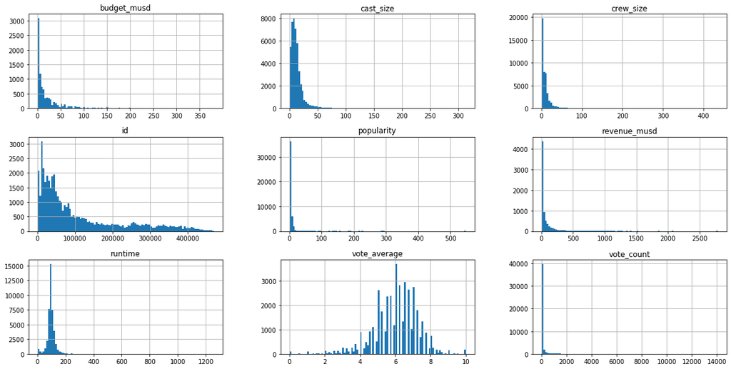

```python
## Numerical fields' visualization
df.hist(figsize = (20, 10), bins = 100)
plt.show()
```

```python
## Which movies-genres has highest reviews
ratings = df.groupby(['id', 'genres'], as_index=False)['vote_average'].aggregate(np.mean)
ratings.head()
```

|  | id | genres | vote_average |
| --- | --- | --- | --- |
| 0 | 2 | Drama\|Crime | 7.10 |
| 1 | 3 | Drama\|Comedy | 7.10 |
| 2 | 5 | Crime\|Comedy | 6.50 |
| 3 | 6 | Action\|Thriller\|Crime | 6.40 |
| 4 | 11 | Adventure\|Action\|Science Fiction | 8.10 |

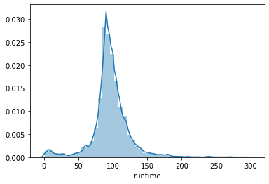

```python
## How many have highest runtime over the period?
import seaborn as sns
sns.distplot(df[(df['runtime'] <300) & (df['runtime']>0)]['runtime'])
```

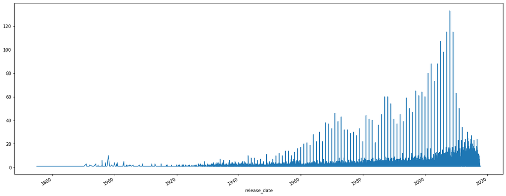

```python
## How many movies in years have been released?
released = df.groupby('release_date')['title'].count()
released.plot(figsize=(20,8))
```

## Step 2 : Data Processing & Analysis

## Identifying Best & Worst Movies

### Setting crieteria for selection : budget, revenue, voting & popularity

```python
## Arrange best 50 movies in descending order of profit then return
df_best.head(50).sort_values(['profit_musd','return'],ascending = False)
```

|  | poster_path | title | budget_musd | revenue_musd | vote_count | vote_average | popularity | profit_musd | return |
| --- | --- | --- | --- | --- | --- | --- | --- | --- | --- |
| 0 | <img src='http://image.tmdb.org/t/p/w185//uXDf... | Toy Story | 30.00 | 373.55 | 5415.00 | 7.70 | 21.95 | 343.55 | 12.45 |
| 46 | <img src='http://image.tmdb.org/t/p/w185//GQP6... | Se7en | 33.00 | 327.31 | 5915.00 | 8.10 | 18.46 | 294.31 | 9.92 |
| 9 | <img src='http://image.tmdb.org/t/p/w185//z0lj... | GoldenEye | 58.00 | 352.19 | 1194.00 | 6.60 | 14.69 | 294.19 | 6.07 |
| 47 | <img src='http://image.tmdb.org/t/p/w185//kZ1f... | Pocahontas | 55.00 | 346.08 | 1509.00 | 6.70 | 13.28 | 291.08 | 6.29 |
| 33 | <img src='http://image.tmdb.org/t/p/w185//kf34... | Babe | 30.00 | 254.13 | 756.00 | 6.00 | 14.40 | 224.13 | 8.47 |
| 1 | <img src='http://image.tmdb.org/t/p/w185//vgpX... | Jumanji | 65.00 | 262.80 | 2413.00 | 6.90 | 17.02 | 197.80 | 4.04 |
| 18 | <img src='http://image.tmdb.org/t/p/w185//wcin... | Ace Ventura: When Nature Calls | 30.00 | 212.39 | 1128.00 | 6.10 | 8.21 | 182.39 | 7.08 |
| 31 | <img src='http://image.tmdb.org/t/p/w185//2F9K... | Twelve Monkeys | 29.50 | 168.84 | 2470.00 | 7.40 | 12.30 | 139.34 | 5.72 |
| 5 | <img src='http://image.tmdb.org/t/p/w185//lbf2... | Heat | 60.00 | 187.44 | 1886.00 | 7.70 | 17.92 | 127.44 | 3.12 |
| 16 | <img src='http://image.tmdb.org/t/p/w185//1ryN... | Sense and Sensibility | 16.50 | 135.00 | 364.00 | 7.20 | 10.67 | 118.50 | 8.18 |
| 43 | <img src='http://image.tmdb.org/t/p/w185//eUdh... | Mortal Kombat | 18.00 | 122.20 | 452.00 | 5.40 | 10.87 | 104.20 | 6.79 |
| 20 | <img src='http://image.tmdb.org/t/p/w185//enHk... | Get Shorty | 30.25 | 115.10 | 305.00 | 6.40 | 12.67 | 84.85 | 3.81 |
| 3 | <img src='http://image.tmdb.org/t/p/w185//4wjG... | Waiting to Exhale | 16.00 | 81.45 | 34.00 | 6.10 | 3.86 | 65.45 | 5.09 |
| 15 | <img src='http://image.tmdb.org/t/p/w185//13jm... | Casino | 52.00 | 116.11 | 1343.00 | 7.80 | 10.14 | 64.11 | 2.23 |
| 24 | <img src='http://image.tmdb.org/t/p/w185//rl5R... | Leaving Las Vegas | 3.60 | 49.80 | 365.00 | 7.10 | 10.33 | 46.20 | 13.83 |
| 10 | <img src='http://image.tmdb.org/t/p/w185//yObO... | The American President | 62.00 | 107.88 | 199.00 | 6.50 | 6.32 | 45.88 | 1.74 |
| 8 | <img src='http://image.tmdb.org/t/p/w185//gV1V... | Sudden Death | 35.00 | 64.35 | 174.00 | 5.50 | 5.23 | 29.35 | 1.84 |
| 35 | <img src='http://image.tmdb.org/t/p/w185//njn4... | Dead Man Walking | 11.00 | 39.36 | 350.00 | 7.30 | 6.89 | 28.36 | 3.58 |
| 49 | <img src='http://image.tmdb.org/t/p/w185//6Dr8... | The Usual Suspects | 6.00 | 23.34 | 3334.00 | 8.10 | 16.30 | 17.34 | 3.89 |
| 26 | <img src='http://image.tmdb.org/t/p/w185//yQ8x... | Now and Then | 12.00 | 27.40 | 91.00 | 6.60 | 8.68 | 15.40 | 2.28 |
| 45 | <img src='http://image.tmdb.org/t/p/w185//kFVx... | How To Make An American Quilt | 10.00 | 23.57 | 38.00 | 6.50 | 4.49 | 13.57 | 2.36 |
| 44 | <img src='http://image.tmdb.org/t/p/w185//aedh... | To Die For | 20.00 | 21.28 | 177.00 | 6.70 | 10.45 | 1.28 | 1.06 |
| 17 | <img src='http://image.tmdb.org/t/p/w185//xhU6... | Four Rooms | 4.00 | 4.30 | 539.00 | 6.50 | 9.03 | 0.30 | 1.07 |
| 28 | <img src='http://image.tmdb.org/t/p/w185//zIIW... | The City of Lost Children | 18.00 | 1.74 | 308.00 | 7.60 | 9.82 | -16.26 | 0.10 |
| 22 | <img src='http://image.tmdb.org/t/p/w185//9LaH... | Assassins | 50.00 | 30.30 | 394.00 | 6.00 | 11.07 | -19.70 | 0.61 |
| 19 | <img src='http://image.tmdb.org/t/p/w185//jWBD... | Money Train | 60.00 | 35.43 | 224.00 | 5.40 | 7.34 | -24.57 | 0.59 |
| 13 | <img src='http://image.tmdb.org/t/p/w185//yzMS... | Nixon | 44.00 | 13.68 | 72.00 | 7.10 | 5.09 | -30.32 | 0.31 |
| 14 | <img src='http://image.tmdb.org/t/p/w185//hYde... | Cutthroat Island | 98.00 | 10.02 | 137.00 | 5.70 | 7.28 | -87.98 | 0.10 |
| 2 | <img src='http://image.tmdb.org/t/p/w185//1FSX... | Grumpier Old Men | nan | nan | 92.00 | 6.50 | 11.71 | nan | nan |
| 4 | <img src='http://image.tmdb.org/t/p/w185//lf9R... | Father of the Bride Part II | nan | 76.58 | 173.00 | 5.70 | 8.39 | nan | nan |
| 6 | <img src='http://image.tmdb.org/t/p/w185//z1oN... | Sabrina | 58.00 | nan | 141.00 | 6.20 | 6.68 | nan | nan |
| 7 | <img src='http://image.tmdb.org/t/p/w185//6yox... | Tom and Huck | nan | nan | 45.00 | 5.40 | 2.56 | nan | nan |
| 11 | <img src='http://image.tmdb.org/t/p/w185//4rRf... | Dracula: Dead and Loving It | nan | nan | 210.00 | 5.70 | 5.43 | nan | nan |
| 12 | <img src='http://image.tmdb.org/t/p/w185//tpoa... | Balto | nan | 11.35 | 423.00 | 7.10 | 12.14 | nan | nan |
| 21 | <img src='http://image.tmdb.org/t/p/w185//fdYw... | Copycat | nan | nan | 199.00 | 6.50 | 10.70 | nan | nan |
| 23 | <img src='http://image.tmdb.org/t/p/w185//kImK... | Powder | nan | nan | 143.00 | 6.30 | 12.13 | nan | nan |
| 25 | <img src='http://image.tmdb.org/t/p/w185//6u14... | Othello | nan | nan | 33.00 | 7.00 | 1.85 | nan | nan |
| 27 | <img src='http://image.tmdb.org/t/p/w185//tYOF... | Persuasion | nan | nan | 36.00 | 7.40 | 2.23 | nan | nan |
| 29 | <img src='http://image.tmdb.org/t/p/w185//x6SZ... | Shanghai Triad | nan | nan | 17.00 | 6.50 | 1.10 | nan | nan |
| 30 | <img src='http://image.tmdb.org/t/p/w185//vzAm... | Dangerous Minds | nan | 180.00 | 249.00 | 6.40 | 9.48 | nan | nan |
| 32 | <img src='http://image.tmdb.org/t/p/w185//hSfI... | Wings of Courage | nan | nan | 4.00 | 6.80 | 0.75 | nan | nan |
| 34 | <img src='http://image.tmdb.org/t/p/w185//8Nme... | Carrington | nan | nan | 16.00 | 6.40 | 1.49 | nan | nan |
| 36 | <img src='http://image.tmdb.org/t/p/w185//lKOA... | Across the Sea of Time | nan | nan | 2.00 | 3.50 | 0.11 | nan | nan |
| 37 | <img src='http://image.tmdb.org/t/p/w185//sdes... | It Takes Two | nan | nan | 149.00 | 6.10 | 7.78 | nan | nan |
| 38 | <img src='http://image.tmdb.org/t/p/w185//8AwV... | Clueless | 12.00 | nan | 828.00 | 6.90 | 9.88 | nan | nan |
| 39 | <img src='http://image.tmdb.org/t/p/w185//kGPs... | Cry, the Beloved Country | nan | 0.68 | 13.00 | 6.70 | 0.89 | nan | nan |
| 40 | <img src='http://image.tmdb.org/t/p/w185//aN2B... | Richard III | nan | nan | 50.00 | 6.90 | 4.56 | nan | nan |
| 41 | <img src='http://image.tmdb.org/t/p/w185//gCqf... | Dead Presidents | 10.00 | nan | 80.00 | 6.60 | 9.88 | nan | nan |
| 42 | <img src='http://image.tmdb.org/t/p/w185//wkf0... | Restoration | 19.00 | nan | 30.00 | 6.30 | 10.98 | nan | nan |
| 48 | <img src='http://image.tmdb.org/t/p/w185//f9ed... | When Night Is Falling | nan | nan | 10.00 | 5.90 | 3.30 | nan | nan |

```python
## Top 5 movies HTML Link and Title
top_5 = df_best.iloc[:5, :2]
top_5
```

|  | poster_path | title |
| --- | --- | --- |
| 0 | <img src='http://image.tmdb.org/t/p/w185//uXDf... | Toy Story |
| 1 | <img src='http://image.tmdb.org/t/p/w185//vgpX... | Jumanji |
| 2 | <img src='http://image.tmdb.org/t/p/w185//1FSX... | Grumpier Old Men |
| 3 | <img src='http://image.tmdb.org/t/p/w185//4wjG... | Waiting to Exhale |
| 4 | <img src='http://image.tmdb.org/t/p/w185//lf9R... | Father of the Bride Part II |

```python
HTML(top_5.to_html(escape=False))
```

|  | poster_path | title |
| --- | --- | --- |
| 0 |  | Toy Story |
| 1 |  | Jumanji |
| 2 |  | Grumpier Old Men |
| 3 |  | Waiting to Exhale |
| 4 |  | Father of the Bride Part II |

```python
## High budget movies with high rate of return and high profits
df_best.loc[df_best.budget_musd >= 300].sort_values(by = "return", ascending = False)
```

|  | poster_path | title | budget_musd | revenue_musd | vote_count | vote_average | popularity | profit_musd | return |
| --- | --- | --- | --- | --- | --- | --- | --- | --- | --- |
| 11743 | <img src='http://image.tmdb.org/t/p/w185//oVh3... | Pirates of the Caribbean: At World's End | 300.00 | 961.00 | 4627.00 | 6.90 | 31.36 | 661.00 | 3.20 |
| 16986 | <img src='http://image.tmdb.org/t/p/w185//keGf... | Pirates of the Caribbean: On Stranger Tides | 380.00 | 1045.71 | 5068.00 | 6.40 | 27.89 | 665.71 | 2.75 |

## Searching as per Priorities

### Search 1: Science Fiction Action Movie with Bruce Willis (with high Rating)

```python
df.cast[0]
```

```
'Tom Hanks|Tim Allen|Don Rickles|Jim Varney|Wallace Shawn|John Ratzenberger|Annie Potts|John Morris|Erik von Detten|Laurie Metcalf|R. Lee Ermey|Sarah Freeman|Penn Jillette'
```

```python
HTML(bruce.to_html(escape=False))
```

| title | poster_path | vote_average |
| --- | --- | --- |
| The Fifth Element |  | 7.30 |
| Looper |  | 6.60 |
| Armageddon |  | 6.50 |
| Surrogates |  | 5.90 |
| G.I. Joe: Retaliation |  | 5.40 |
| Vice |  | 4.10 |

### : Seach 2: Most Successful Pixar Studio Movies between 2010 and 2015 (high Revenue)

```python
HTML(pixar.head(5).to_html(escape=False))
```

| title | poster_path | revenue_musd | release_date |
| --- | --- | --- | --- |
| Toy Story 3 |  | 1066.97 | 2010-06-16 |
| Inside Out |  | 857.61 | 2015-06-09 |
| Monsters University |  | 743.56 | 2013-06-20 |
| Cars 2 |  | 559.85 | 2011-06-11 |
| Brave |  | 538.98 | 2012-06-21 |

### Search 3: Action or Thriller Movie in English and minimum Rating of 7.5 (latest one)

```python
HTML(next_mov.to_html(escape=False))
```

| title | poster_path | genres | vote_average | vote_count | release_date |
| --- | --- | --- | --- | --- | --- |
| Descendants 2 |  | TV Movie\|Family\|Action\|Comedy\|Music\|Adventure | 7.50 | 171.00 | 2017-07-21 |
| Dunkirk |  | Action\|Drama\|History\|Thriller\|War | 7.50 | 2712.00 | 2017-07-19 |
| The Book of Henry |  | Thriller\|Drama\|Crime | 7.60 | 84.00 | 2017-06-16 |
| Guardians of the Galaxy Vol. 2 |  | Action\|Adventure\|Comedy\|Science Fiction | 7.60 | 4858.00 | 2017-04-19 |
| Logan |  | Action\|Drama\|Science Fiction | 7.60 | 6310.00 | 2017-02-28 |
| The Thinning |  | Thriller | 7.60 | 92.00 | 2016-10-12 |
| 11.22.63 |  | Drama\|History\|Thriller | 8.00 | 213.00 | 2016-02-15 |
| Star Wars: The Force Awakens |  | Action\|Adventure\|Science Fiction\|Fantasy | 7.50 | 7993.00 | 2015-12-15 |
| London Spy |  | Romance\|Crime\|Drama\|Mystery\|Thriller | 8.80 | 12.00 | 2015-11-09 |
| Spotlight |  | Drama\|Thriller\|History | 7.80 | 2751.00 | 2015-11-06 |
| Room |  | Drama\|Thriller | 8.10 | 2838.00 | 2015-10-16 |
| The Fear of 13 |  | Thriller\|Documentary | 8.00 | 45.00 | 2015-10-15 |
| 3 ½ Minutes, 10 Bullets |  | Thriller\|Documentary | 7.80 | 30.00 | 2015-10-02 |
| An Inspector Calls |  | Drama\|Crime\|Thriller | 7.60 | 42.00 | 2015-09-13 |
| Kung Fury |  | Action\|Comedy\|Science Fiction\|Fantasy | 7.60 | 762.00 | 2015-05-22 |
| Kingsman: The Secret Service |  | Crime\|Comedy\|Action\|Adventure | 7.60 | 6069.00 | 2015-01-29 |
| Black Mirror: White Christmas |  | Drama\|Horror\|Mystery\|Science Fiction\|Thriller\|TV Movie | 8.30 | 211.00 | 2014-12-16 |
| The Imitation Game |  | History\|Drama\|Thriller\|War | 8.00 | 5895.00 | 2014-11-14 |
| Big Hero 6 |  | Adventure\|Family\|Animation\|Action\|Comedy | 7.80 | 6289.00 | 2014-10-24 |
| Nightcrawler |  | Crime\|Drama\|Thriller | 7.60 | 3475.00 | 2014-10-23 |

## Seach 4: Most Successful Franchises

```python
franchises = df.groupby("belongs_to_collection").agg({"title":"count", "budget_musd": ["sum", "mean"],
                                                      "revenue_musd": ["sum", "mean"],
                                                      "vote_average": "mean", "popularity": "mean",
                                                      "ROI":"median",
                                                      "vote_count":"mean"})
```

```python
franchises
```

| belongs_to_collection | title count | budget_musd sum | budget_musd mean | revenue_musd sum | revenue_musd mean | vote_average mean | popularity mean | ROI median | vote_count mean |
| --- | --- | --- | --- | --- | --- | --- | --- | --- | --- |
| ... Has Fallen Collection | 2 | 130.00 | 65.00 | 366.78 | 183.39 | 6.00 | 13.01 | 2.86 | 2333.00 |
| 00 Schneider Filmreihe | 1 | 0.00 | nan | 0.00 | nan | 6.50 | 1.93 | nan | 16.00 |
| 08/15 Collection | 1 | 0.00 | nan | 0.00 | nan | 5.90 | 0.63 | nan | 4.00 |
| 100 Girls Collection | 2 | 0.00 | nan | 0.00 | nan | 5.15 | 3.08 | nan | 64.00 |
| 101 Dalmatians (Animated) Collection | 2 | 4.00 | 4.00 | 215.88 | 215.88 | 6.25 | 13.06 | 53.97 | 937.00 |
| ... | ... | ... | ... | ... | ... | ... | ... | ... | ... |
| Сказки Чуковского | 1 | 0.00 | nan | 0.00 | nan | 3.00 | 0.73 | nan | 3.00 |
| Чебурашка и крокодил Гена | 1 | 0.00 | nan | 0.00 | nan | 6.70 | 0.88 | nan | 7.00 |
| Что Творят мужчины! (Коллекция) | 2 | 2.00 | 2.00 | 0.00 | nan | 3.15 | 1.30 | nan | 5.50 |
| 男はつらいよ シリーズ | 3 | 0.00 | nan | 0.00 | nan | 7.00 | 0.04 | nan | 0.67 |
| 식객 시리즈 | 2 | 0.00 | nan | 0.00 | nan | 4.95 | 0.16 | nan | 3.50 |

1691 rows × 9 columns

```python
franchises.nlargest(20, ("revenue_musd", "mean"))
```

| belongs_to_collection | title count | budget_musd sum | budget_musd mean | revenue_musd sum | revenue_musd mean | vote_average mean | popularity mean | ROI median | vote_count mean |
| --- | --- | --- | --- | --- | --- | --- | --- | --- | --- |
| Avatar Collection | 1 | 237.00 | 237.00 | 2787.97 | 2787.97 | 7.20 | 185.07 | 11.76 | 12114.00 |
| The Avengers Collection | 2 | 500.00 | 250.00 | 2924.96 | 1462.48 | 7.35 | 63.63 | 5.96 | 9454.00 |
| Frozen Collection | 2 | 150.00 | 150.00 | 1274.22 | 1274.22 | 7.10 | 16.88 | 8.49 | 3035.00 |
| Finding Nemo Collection | 2 | 294.00 | 147.00 | 1968.91 | 984.45 | 7.20 | 19.99 | 7.57 | 5312.50 |
| The Hobbit Collection | 3 | 750.00 | 250.00 | 2935.52 | 978.51 | 7.23 | 25.21 | 3.83 | 5981.33 |
| The Lord of the Rings Collection | 3 | 266.00 | 88.67 | 2916.54 | 972.18 | 8.03 | 30.27 | 11.73 | 8253.00 |
| Harry Potter Collection | 8 | 1280.00 | 160.00 | 7707.37 | 963.42 | 7.54 | 26.25 | 6.17 | 5983.25 |
| Star Wars Collection | 8 | 854.35 | 106.79 | 7434.49 | 929.31 | 7.37 | 23.41 | 8.24 | 5430.38 |
| Despicable Me Collection | 6 | 299.00 | 74.75 | 3691.07 | 922.77 | 6.78 | 106.72 | 12.76 | 3041.33 |
| Pirates of the Caribbean Collection | 5 | 1250.00 | 250.00 | 4521.58 | 904.32 | 6.88 | 53.97 | 3.45 | 5016.00 |
| The Secret Life of Pets Collection | 1 | 75.00 | 75.00 | 875.46 | 875.46 | 5.90 | 11.01 | 11.67 | 3536.00 |
| Transformers Collection | 5 | 965.00 | 193.00 | 4366.10 | 873.22 | 6.14 | 14.43 | 5.20 | 3046.40 |
| Spider-Man Collection | 3 | 597.00 | 199.00 | 2496.35 | 832.12 | 6.47 | 22.62 | 3.92 | 4505.67 |
| The Dark Knight Collection | 3 | 585.00 | 195.00 | 2463.72 | 821.24 | 7.80 | 57.42 | 4.34 | 9681.00 |
| Wonder Woman Collection | 1 | 149.00 | 149.00 | 820.58 | 820.58 | 7.20 | 294.34 | 5.51 | 5025.00 |
| Guardians of the Galaxy Collection | 2 | 370.00 | 185.00 | 1636.74 | 818.37 | 7.75 | 119.31 | 4.43 | 7436.00 |
| Fantastic Beasts Collection | 1 | 180.00 | 180.00 | 809.34 | 809.34 | 7.20 | 41.05 | 4.50 | 5612.00 |
| Iron Man Collection | 3 | 540.00 | 180.00 | 2424.55 | 808.18 | 6.93 | 21.63 | 4.18 | 8290.33 |
| The Lion King Collection | 4 | 45.00 | 45.00 | 788.24 | 788.24 | 6.75 | 11.48 | 17.52 | 1827.50 |
| Deadpool Collection | 1 | 58.00 | 58.00 | 783.11 | 783.11 | 7.40 | 187.86 | 13.50 | 11444.00 |

```python
franchises[franchises[("vote_count", "mean")] >=1000].nlargest(20, ("vote_average", "mean"))
```

| belongs_to_collection | title count | budget_musd sum | budget_musd mean | revenue_musd sum | revenue_musd mean | vote_average mean | popularity mean | ROI median | vote_count mean |
| --- | --- | --- | --- | --- | --- | --- | --- | --- | --- |
| The Lord of the Rings Collection | 3 | 266.00 | 88.67 | 2916.54 | 972.18 | 8.03 | 30.27 | 11.73 | 8253.00 |
| The Godfather Collection | 3 | 73.00 | 24.33 | 429.38 | 143.13 | 7.97 | 31.64 | 3.66 | 3677.00 |
| Blade Runner Collection | 1 | 28.00 | 28.00 | 33.14 | 33.14 | 7.90 | 96.27 | 1.18 | 3833.00 |
| The Man With No Name Collection | 3 | 2.00 | 0.67 | 35.50 | 11.83 | 7.83 | 14.17 | 25.00 | 1422.67 |
| The Dark Knight Collection | 3 | 585.00 | 195.00 | 2463.72 | 821.24 | 7.80 | 57.42 | 4.34 | 9681.00 |
| Guardians of the Galaxy Collection | 2 | 370.00 | 185.00 | 1636.74 | 818.37 | 7.75 | 119.31 | 4.43 | 7436.00 |
| Kill Bill Collection | 2 | 60.00 | 30.00 | 333.11 | 166.55 | 7.70 | 23.40 | 5.55 | 4576.00 |
| Kingsman Collection | 1 | 81.00 | 81.00 | 414.35 | 414.35 | 7.60 | 28.22 | 5.12 | 6069.00 |
| How to Train Your Dragon Collection | 2 | 310.00 | 155.00 | 1104.00 | 552.00 | 7.55 | 13.34 | 3.60 | 3741.00 |
| Harry Potter Collection | 8 | 1280.00 | 160.00 | 7707.37 | 963.42 | 7.54 | 26.25 | 6.17 | 5983.25 |
| Toy Story Collection | 3 | 320.00 | 106.67 | 1937.89 | 645.96 | 7.53 | 18.82 | 5.53 | 4679.67 |
| Back to the Future Collection | 3 | 99.00 | 33.00 | 957.64 | 319.21 | 7.50 | 17.50 | 8.30 | 4381.00 |
| Trainspotting Collection | 2 | 22.00 | 11.00 | 57.90 | 28.95 | 7.45 | 18.50 | 3.21 | 1766.00 |
| Deadpool Collection | 1 | 58.00 | 58.00 | 783.11 | 783.11 | 7.40 | 187.86 | 13.50 | 11444.00 |
| The Incredibles Collection | 1 | 92.00 | 92.00 | 631.44 | 631.44 | 7.40 | 22.22 | 6.86 | 5290.00 |
| Star Wars Collection | 8 | 854.35 | 106.79 | 7434.49 | 929.31 | 7.37 | 23.41 | 8.24 | 5430.38 |
| The Avengers Collection | 2 | 500.00 | 250.00 | 2924.96 | 1462.48 | 7.35 | 63.63 | 5.96 | 9454.00 |
| The Lego Movie Collection | 2 | 140.00 | 70.00 | 781.11 | 390.56 | 7.35 | 16.74 | 5.86 | 2300.00 |
| Tangled Collection | 2 | 260.00 | 260.00 | 591.79 | 591.79 | 7.25 | 12.32 | 2.28 | 1901.00 |
| The Space Odyssey Series | 2 | 38.50 | 19.25 | 109.10 | 54.55 | 7.25 | 14.99 | 3.99 | 1682.50 |

## Seach 6: Most Successful Directors

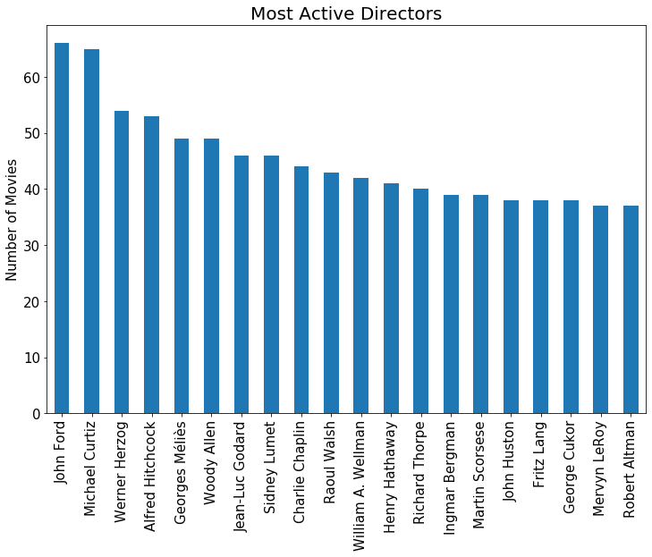

```python
plt.figure(figsize = (12, 8))
df.director.value_counts().head(20).plot(kind='bar', fontsize = 15)
plt.title("Most Active Directors",fontsize = 20)
plt.ylabel("Number of Movies", fontsize = 15)
plt.show()
```

```python
df.groupby("director").revenue_musd.sum().nlargest(20)
```

```
director
Steven Spielberg    9256.62
Peter Jackson       6528.24
Michael Bay         6437.47
James Cameron       5900.61
David Yates         5334.56
Christopher Nolan   4747.41
Robert Zemeckis     4138.23
Tim Burton          4032.92
Ridley Scott        3917.53
Chris Columbus      3866.84
Roland Emmerich     3798.40
Ron Howard          3714.15
J.J. Abrams         3579.22
Gore Verbinski      3575.34
George Lucas        3341.55
Sam Raimi           3193.79
Francis Lawrence    3183.34
Clint Eastwood      3100.68
Bill Condon         3017.30
Joss Whedon         2963.83
Name: revenue_musd, dtype: float64
```

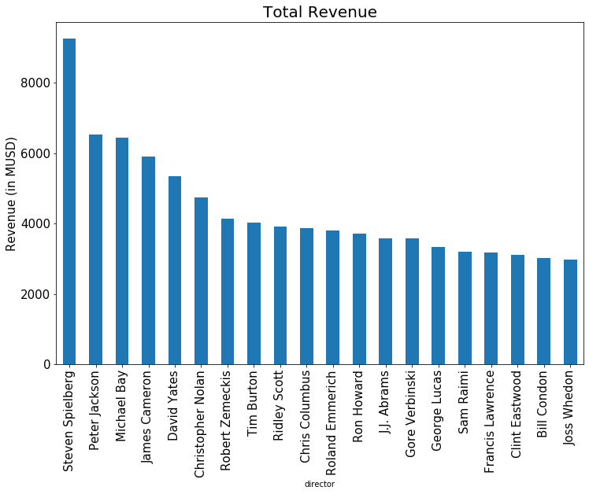

```python
plt.figure(figsize = (12, 8))
df.groupby("director").revenue_musd.sum().nlargest(20).plot(kind='bar', fontsize = 15)
plt.title("Total Revenue",fontsize = 20)
plt.ylabel("Revenue (in MUSD)", fontsize = 15)
plt.show()
```

## Search 7: Most Successful Actors

```python
df.cast
```

```
0        Tom Hanks|Tim Allen|Don Rickles|Jim Varney|Wal...
1        Robin Williams|Jonathan Hyde|Kirsten Dunst|Bra...
2        Walter Matthau|Jack Lemmon|Ann-Margret|Sophia ...
3        Whitney Houston|Angela Bassett|Loretta Devine|...
4        Steve Martin|Diane Keaton|Martin Short|Kimberl...
                               ...
44686              Leila Hatami|Kourosh Tahami|Elham Korda
44687    Angel Aquino|Perry Dizon|Hazel Orencio|Joel To...
44688    Erika Eleniak|Adam Baldwin|Julie du Page|James...
44689    Iwan Mosschuchin|Nathalie Lissenko|Pavel Pavlo...
44690                                                  NaN
Name: cast, Length: 44691, dtype: object
```

```python
df
```

|  | id | title | tagline | release_date | genres | belongs_to_collection | original_language | budget_musd | revenue_musd | production_companies | production_countries | vote_count | vote_average | popularity | runtime | overview | spoken_languages | poster_path | cast | cast_size | crew_size | director | Franchise | ROI |
| --- | --- | --- | --- | --- | --- | --- | --- | --- | --- | --- | --- | --- | --- | --- | --- | --- | --- | --- | --- | --- | --- | --- | --- | --- |
| 0 | 862 | Toy Story | NaN | 1995-10-30 | Animation\|Comedy\|Family | Toy Story Collection | en | 30.00 | 373.55 | Pixar Animation Studios | United States of America | 5415.00 | 7.70 | 21.95 | 81.00 | Led by Woody, Andy's toys live happily in his ... | English | <img src='http://image.tmdb.org/t/p/w185//uXDf... | Tom Hanks\|Tim Allen\|Don Rickles\|Jim Varney\|Wal... | 13 | 106 | John Lasseter | True | 12.45 |
| 1 | 8844 | Jumanji | Roll the dice and unleash the excitement! | 1995-12-15 | Adventure\|Fantasy\|Family | NaN | en | 65.00 | 262.80 | TriStar Pictures\|Teitler Film\|Interscope Commu... | United States of America | 2413.00 | 6.90 | 17.02 | 104.00 | When siblings Judy and Peter discover an encha... | English\|Français | <img src='http://image.tmdb.org/t/p/w185//vgpX... | Robin Williams\|Jonathan Hyde\|Kirsten Dunst\|Bra... | 26 | 16 | Joe Johnston | False | 4.04 |
| 2 | 15602 | Grumpier Old Men | Still Yelling. Still Fighting. Still Ready for... | 1995-12-22 | Romance\|Comedy | Grumpy Old Men Collection | en | nan | nan | Warner Bros.\|Lancaster Gate | United States of America | 92.00 | 6.50 | 11.71 | 101.00 | A family wedding reignites the ancient feud be... | English | <img src='http://image.tmdb.org/t/p/w185//1FSX... | Walter Matthau\|Jack Lemmon\|Ann-Margret\|Sophia ... | 7 | 4 | Howard Deutch | True | nan |
| 3 | 31357 | Waiting to Exhale | Friends are the people who let you be yourself... | 1995-12-22 | Comedy\|Drama\|Romance | NaN | en | 16.00 | 81.45 | Twentieth Century Fox Film Corporation | United States of America | 34.00 | 6.10 | 3.86 | 127.00 | Cheated on, mistreated and stepped on, the wom... | English | <img src='http://image.tmdb.org/t/p/w185//4wjG... | Whitney Houston\|Angela Bassett\|Loretta Devine\|... | 10 | 10 | Forest Whitaker | False | 5.09 |
| 4 | 11862 | Father of the Bride Part II | Just When His World Is Back To Normal... He's ... | 1995-02-10 | Comedy | Father of the Bride Collection | en | nan | 76.58 | Sandollar Productions\|Touchstone Pictures | United States of America | 173.00 | 5.70 | 8.39 | 106.00 | Just when George Banks has recovered from his ... | English | <img src='http://image.tmdb.org/t/p/w185//lf9R... | Steve Martin\|Diane Keaton\|Martin Short\|Kimberl... | 12 | 7 | Charles Shyer | True | nan |
| ... | ... | ... | ... | ... | ... | ... | ... | ... | ... | ... | ... | ... | ... | ... | ... | ... | ... | ... | ... | ... | ... | ... | ... | ... |
| 44686 | 439050 | Subdue | Rising and falling between a man and woman | NaT | Drama\|Family | NaN | fa | nan | nan | NaN | Iran | 1.00 | 4.00 | 0.07 | 90.00 | Rising and falling between a man and woman. | فارسی | <img src='http://image.tmdb.org/t/p/w185//pfC8... | Leila Hatami\|Kourosh Tahami\|Elham Korda | 3 | 9 | Hamid Nematollah | False | nan |
| 44687 | 111109 | Century of Birthing | NaN | 2011-11-17 | Drama | NaN | tl | nan | nan | Sine Olivia | Philippines | 3.00 | 9.00 | 0.18 | 360.00 | An artist struggles to finish his work while a... | NaN | <img src='http://image.tmdb.org/t/p/w185//xZkm... | Angel Aquino\|Perry Dizon\|Hazel Orencio\|Joel To... | 11 | 6 | Lav Diaz | False | nan |
| 44688 | 67758 | Betrayal | A deadly game of wits. | 2003-08-01 | Action\|Drama\|Thriller | NaN | en | nan | nan | American World Pictures | United States of America | 6.00 | 3.80 | 0.90 | 90.00 | When one of her hits goes wrong, a professiona... | English | <img src='http://image.tmdb.org/t/p/w185//eGga... | Erika Eleniak\|Adam Baldwin\|Julie du Page\|James... | 15 | 5 | Mark L. Lester | False | nan |
| 44689 | 227506 | Satan Triumphant | NaN | 1917-10-21 | nan | NaN | en | nan | nan | Yermoliev | Russia | 0.00 | nan | 0.00 | 87.00 | In a small town live two brothers, one a minis... | NaN | <img src='http://image.tmdb.org/t/p/w185//aorB... | Iwan Mosschuchin\|Nathalie Lissenko\|Pavel Pavlo... | 5 | 2 | Yakov Protazanov | False | nan |
| 44690 | 461257 | Queerama | NaN | 2017-06-09 | nan | NaN | en | nan | nan | NaN | United Kingdom | 0.00 | nan | 0.16 | 75.00 | 50 years after decriminalisation of homosexual... | English | <img src='http://image.tmdb.org/t/p/w185//oxFE... | NaN | 0 | 1 | Daisy Asquith | False | nan |

44691 rows × 24 columns

```python
df.cast.str.split("|", expand = True)
```

| id | 0 | 1 | 2 | 3 | 4 | 5 | 6 | 7 | 8 | 9 | 10 | 11 | ... | 301 | 302 | 303 | 304 | 305 | 306 | 307 | 308 | 309 | 310 | 311 | 312 |
| --- | --- | --- | --- | --- | --- | --- | --- | --- | --- | --- | --- | --- | --- | --- | --- | --- | --- | --- | --- | --- | --- | --- | --- | --- | --- |
| 862 | Tom Hanks | Tim Allen | Don Rickles | Jim Varney | Wallace Shawn | John Ratzenberger | Annie Potts | John Morris | Erik von Detten | Laurie Metcalf | R. Lee Ermey | Sarah Freeman | ... | None | None | None | None | None | None | None | None | None | None | None | None |
| 8844 | Robin Williams | Jonathan Hyde | Kirsten Dunst | Bradley Pierce | Bonnie Hunt | Bebe Neuwirth | David Alan Grier | Patricia Clarkson | Adam Hann-Byrd | Laura Bell Bundy | James Handy | Gillian Barber | ... | None | None | None | None | None | None | None | None | None | None | None | None |
| 15602 | Walter Matthau | Jack Lemmon | Ann-Margret | Sophia Loren | Daryl Hannah | Burgess Meredith | Kevin Pollak | None | None | None | None | None | ... | None | None | None | None | None | None | None | None | None | None | None | None |
| 31357 | Whitney Houston | Angela Bassett | Loretta Devine | Lela Rochon | Gregory Hines | Dennis Haysbert | Michael Beach | Mykelti Williamson | Lamont Johnson | Wesley Snipes | None | None | ... | None | None | None | None | None | None | None | None | None | None | None | None |
| 11862 | Steve Martin | Diane Keaton | Martin Short | Kimberly Williams-Paisley | George Newbern | Kieran Culkin | BD Wong | Peter Michael Goetz | Kate McGregor-Stewart | Jane Adams | Eugene Levy | Lori Alan | ... | None | None | None | None | None | None | None | None | None | None | None | None |
| ... | ... | ... | ... | ... | ... | ... | ... | ... | ... | ... | ... | ... | ... | ... | ... | ... | ... | ... | ... | ... | ... | ... | ... | ... | ... |
| 439050 | Leila Hatami | Kourosh Tahami | Elham Korda | None | None | None | None | None | None | None | None | None | ... | None | None | None | None | None | None | None | None | None | None | None | None |
| 111109 | Angel Aquino | Perry Dizon | Hazel Orencio | Joel Torre | Bart Guingona | Soliman Cruz | Roeder | Angeli Bayani | Dante Perez | Betty Uy-Regala | Modesta | None | ... | None | None | None | None | None | None | None | None | None | None | None | None |
| 67758 | Erika Eleniak | Adam Baldwin | Julie du Page | James Remar | Damian Chapa | Louis Mandylor | Tom Wright | Jeremy Lelliott | James Quattrochi | Jason Widener | Joe Sabatino | Kiko Ellsworth | ... | None | None | None | None | None | None | None | None | None | None | None | None |
| 227506 | Iwan Mosschuchin | Nathalie Lissenko | Pavel Pavlov | Aleksandr Chabrov | Vera Orlova | None | None | None | None | None | None | None | ... | None | None | None | None | None | None | None | None | None | None | None | None |
| 461257 | NaN | NaN | NaN | NaN | NaN | NaN | NaN | NaN | NaN | NaN | NaN | NaN | ... | NaN | NaN | NaN | NaN | NaN | NaN | NaN | NaN | NaN | NaN | NaN | NaN |

44691 rows × 313 columns

```python
act = df.cast.str.split("|", expand = True)
act
```

| id | 0 | 1 | 2 | 3 | 4 | 5 | 6 | 7 | 8 | 9 | 10 | 11 | ... | 301 | 302 | 303 | 304 | 305 | 306 | 307 | 308 | 309 | 310 | 311 | 312 |
| --- | --- | --- | --- | --- | --- | --- | --- | --- | --- | --- | --- | --- | --- | --- | --- | --- | --- | --- | --- | --- | --- | --- | --- | --- | --- |
| 862 | Tom Hanks | Tim Allen | Don Rickles | Jim Varney | Wallace Shawn | John Ratzenberger | Annie Potts | John Morris | Erik von Detten | Laurie Metcalf | R. Lee Ermey | Sarah Freeman | ... | None | None | None | None | None | None | None | None | None | None | None | None |
| 8844 | Robin Williams | Jonathan Hyde | Kirsten Dunst | Bradley Pierce | Bonnie Hunt | Bebe Neuwirth | David Alan Grier | Patricia Clarkson | Adam Hann-Byrd | Laura Bell Bundy | James Handy | Gillian Barber | ... | None | None | None | None | None | None | None | None | None | None | None | None |
| 15602 | Walter Matthau | Jack Lemmon | Ann-Margret | Sophia Loren | Daryl Hannah | Burgess Meredith | Kevin Pollak | None | None | None | None | None | ... | None | None | None | None | None | None | None | None | None | None | None | None |
| 31357 | Whitney Houston | Angela Bassett | Loretta Devine | Lela Rochon | Gregory Hines | Dennis Haysbert | Michael Beach | Mykelti Williamson | Lamont Johnson | Wesley Snipes | None | None | ... | None | None | None | None | None | None | None | None | None | None | None | None |
| 11862 | Steve Martin | Diane Keaton | Martin Short | Kimberly Williams-Paisley | George Newbern | Kieran Culkin | BD Wong | Peter Michael Goetz | Kate McGregor-Stewart | Jane Adams | Eugene Levy | Lori Alan | ... | None | None | None | None | None | None | None | None | None | None | None | None |
| ... | ... | ... | ... | ... | ... | ... | ... | ... | ... | ... | ... | ... | ... | ... | ... | ... | ... | ... | ... | ... | ... | ... | ... | ... | ... |
| 439050 | Leila Hatami | Kourosh Tahami | Elham Korda | None | None | None | None | None | None | None | None | None | ... | None | None | None | None | None | None | None | None | None | None | None | None |
| 111109 | Angel Aquino | Perry Dizon | Hazel Orencio | Joel Torre | Bart Guingona | Soliman Cruz | Roeder | Angeli Bayani | Dante Perez | Betty Uy-Regala | Modesta | None | ... | None | None | None | None | None | None | None | None | None | None | None | None |
| 67758 | Erika Eleniak | Adam Baldwin | Julie du Page | James Remar | Damian Chapa | Louis Mandylor | Tom Wright | Jeremy Lelliott | James Quattrochi | Jason Widener | Joe Sabatino | Kiko Ellsworth | ... | None | None | None | None | None | None | None | None | None | None | None | None |
| 227506 | Iwan Mosschuchin | Nathalie Lissenko | Pavel Pavlov | Aleksandr Chabrov | Vera Orlova | None | None | None | None | None | None | None | ... | None | None | None | None | None | None | None | None | None | None | None | None |
| 461257 | NaN | NaN | NaN | NaN | NaN | NaN | NaN | NaN | NaN | NaN | NaN | NaN | ... | NaN | NaN | NaN | NaN | NaN | NaN | NaN | NaN | NaN | NaN | NaN | NaN |

44691 rows × 313 columns

```python
act.columns = ["Actor"]
```

```python
act = act.merge(df[["title", "revenue_musd", "vote_average", "popularity"]],
                how = "left", left_index = True, right_index = True)
```

```python
act
```

| id | Actor | title | revenue_musd | vote_average | popularity |
| --- | --- | --- | --- | --- | --- |
| 2 | Turo Pajala | Ariel | nan | 7.10 | 3.86 |
| 2 | Susanna Haavisto | Ariel | nan | 7.10 | 3.86 |
| 2 | Matti Pellonpää | Ariel | nan | 7.10 | 3.86 |
| 2 | Eetu Hilkamo | Ariel | nan | 7.10 | 3.86 |
| 3 | Matti Pellonpää | Shadows in Paradise | nan | 7.10 | 2.29 |
| ... | ... | ... | ... | ... | ... |
| 469172 | Vasco Sequeira | Manuel on the Island of Wonders | nan | nan | 0.00 |
| 469172 | Armanda Bacelar | Manuel on the Island of Wonders | nan | nan | 0.00 |
| 469172 | Rafael de Sousa | Manuel on the Island of Wonders | nan | nan | 0.00 |
| 469172 | José Antônio Gomes | Manuel on the Island of Wonders | nan | nan | 0.00 |
| 469172 | Isabel Branco | Manuel on the Island of Wonders | nan | nan | 0.00 |

557703 rows × 5 columns

```python
act.Actor.value_counts().head(20)
```

```
Bess Flowers          240
Christopher Lee       148
John Wayne            125
Samuel L. Jackson     122
Michael Caine         110
John Carradine        109
Gérard Depardieu      109
Donald Sutherland     108
Jackie Chan           108
Frank Welker          107
Robert De Niro        104
Steve Buscemi         101
Danny Trejo           101
Irving Bacon           98
John Goodman           97
Christopher Walken     96
Danny Glover           95
John Hurt              93
Susan Sarandon         92
Dennis Hopper          92
Name: Actor, dtype: int64
```

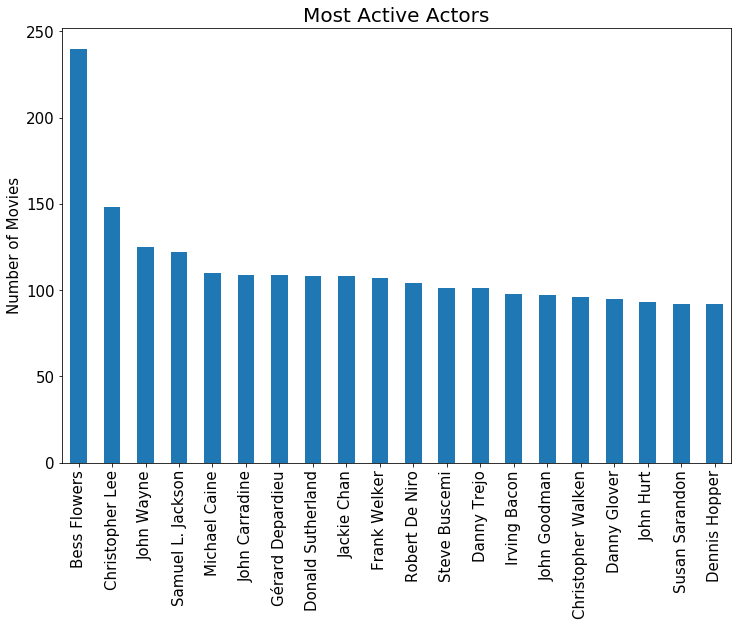

```python
plt.figure(figsize = (12, 8))
act.Actor.value_counts().head(20).plot(kind='bar', fontsize = 15)
plt.title("Most Active Actors",fontsize = 20)
plt.ylabel("Number of Movies", fontsize = 15)
plt.show()
```

```python
agg.nlargest(10, "Total_Movies")
```

| Actor | Total_Revenue | Mean_Revenue | Mean_Rating | Mean_Pop | Total_Movies |
| --- | --- | --- | --- | --- | --- |
| Bess Flowers | 368.91 | 14.76 | 6.18 | 2.03 | 240 |
| Christopher Lee | 9417.05 | 324.73 | 5.91 | 4.75 | 148 |
| John Wayne | 236.09 | 11.24 | 5.71 | 3.09 | 125 |
| Samuel L. Jackson | 17109.62 | 213.87 | 6.27 | 11.70 | 122 |
| Michael Caine | 8053.40 | 191.75 | 6.27 | 8.27 | 110 |
| Gérard Depardieu | 1247.61 | 95.97 | 6.05 | 3.70 | 109 |
| John Carradine | 255.84 | 19.68 | 5.55 | 2.43 | 109 |
| Donald Sutherland | 5390.77 | 138.22 | 6.23 | 7.00 | 108 |
| Jackie Chan | 4699.19 | 146.85 | 6.28 | 5.86 | 108 |
| Frank Welker | 13044.15 | 326.10 | 6.31 | 9.57 | 107 |

```python
agg.nlargest(10, "Total_Revenue")
```

| Actor | Total_Revenue | Mean_Revenue | Mean_Rating | Mean_Pop | Total_Movies |
| --- | --- | --- | --- | --- | --- |
| Stan Lee | 19414.96 | 647.17 | 6.51 | 29.94 | 48 |
| Samuel L. Jackson | 17109.62 | 213.87 | 6.27 | 11.70 | 122 |
| Warwick Davis | 13256.03 | 662.80 | 6.29 | 13.09 | 34 |
| Frank Welker | 13044.15 | 326.10 | 6.31 | 9.57 | 107 |
| John Ratzenberger | 12596.13 | 449.86 | 6.48 | 10.96 | 46 |
| Jess Harnell | 12234.61 | 611.73 | 6.44 | 10.92 | 35 |
| Hugo Weaving | 11027.58 | 459.48 | 6.47 | 10.97 | 40 |
| Ian McKellen | 11015.59 | 478.94 | 6.35 | 15.45 | 44 |
| Johnny Depp | 10653.76 | 217.42 | 6.44 | 12.38 | 69 |
| Alan Rickman | 10612.63 | 353.75 | 6.72 | 10.40 | 45 |

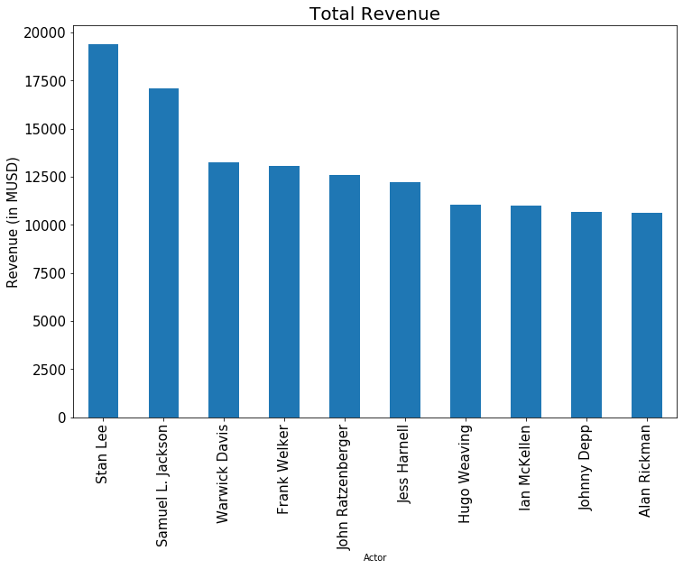

```python
plt.figure(figsize = (12, 8))
agg.Total_Revenue.nlargest(10).plot(kind='bar', fontsize = 15)
plt.title("Total Revenue",fontsize = 20)
plt.ylabel("Revenue (in MUSD)", fontsize = 15)
plt.show()
```